# レポート課題3-2

学籍番号：2094572t  
氏名：木澤 祐人

## テーマ

左右ステレオのマイクで収録された音声信号データから、音のやってきた方向を推定する。

## 準備

まず、Google Driveに格納されているデータを読み込むため，Google Colab からGoogle Driveを参照できるよう、マウント処理を行う。

その後、目的の作業フォルダに移動し、report03_input.csv の存在を確認する。

```python
from google.colab import drive
drive.mount('/content/drive')
%cd /content/drive/'My Drive'/情報管理/03/
%ls
```

```
/content/drive/My Drive/情報管理/03
03_01_moving_average.ipynb        covid19.csv   report_03_01.ipynb
03_02_approximate_function.ipynb  energy.csv    report_03_02.ipynb
03_03_correlation.ipynb           icecream.csv  report03_input.csv
convert_report.ipynb              kishou.csv    sun.csv
```

次に、データ処理に必要なライブラリをインポートする。

```python
import pandas as pd
import numpy as np
import matplotlib.pyplot as plt
```

最後に、

- pandasライブラリを用いてデータを読み込み、
- 各列をnumpyライブラリ用にndarray型データとして抽出する。

```python
csv_data = pd.read_csv('report03_input.csv', encoding='SHIFT-JIS')
left = csv_data.loc[:, 'left'].to_numpy()
right = csv_data.loc[:, 'right'].to_numpy()
```

## 左右マイク間の音声到着のズレ

左右のデータの相互相関関数を計算し、その関数が最大値を調べることで、  
左右間にある増減関係の時間的なズレを調べる。

相互相関関数を求める関数は次のように定義する。

```python
def calc_cross_corr(x, y):

  num_samples = np.size(y)
  cross_corr = np.zeros(num_samples)

  for m in range(num_samples):
    shifted_y = np.zeros(num_samples)
    shifted_y[:num_samples-m] = y[m:]
    cross_corr[m] = np.dot(x, shifted_y)

  return cross_corr
```

次に、見やすさのため左右のデータを標準化したのち、相互相関関数を実際に計算する。  
なお左右間のズレは、  
「左のマイクに比べ右のマイクがどれだけ遅れて音を記録するか」  
で表現する。

```python
left_norm = (left - np.mean(left)) / np.std(left)
right_norm = (right - np.mean(right)) / np.std(right)


corr = calc_cross_corr(left_norm, right_norm)
corr_norm = corr / np.size(left)
```

最後に、得られた相互相関関数をプロットするとともに、最大値をとる時間とその値を出力する。

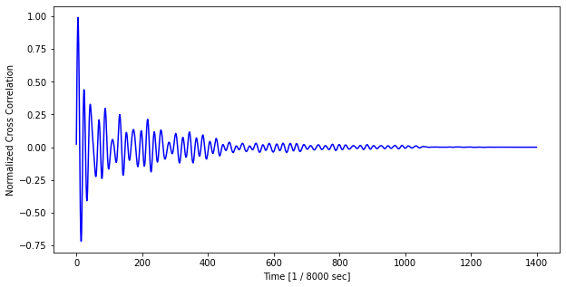

```
argmax of corr_norm = 0.000625 (seconds)
max of corr_norm = 0.991529
```

```python
plt.figure(figsize=(10,5))
x = np.arange(np.size(left))
plt.plot(x, corr_norm, color='b')
plt.xlabel('Time [1 / 8000 sec]')
plt.ylabel('Normalized Cross Correlation')
plt.show()

max_index = np.argmax(corr_norm)
print('argmax of corr_norm = %f (seconds)' % ((max_index) / 8000.0))
print('max of corr_norm = %f' % (np.max(corr_norm)))
```

以上の結果から、相互相関係数は 0.000625 seconds の時に最大となることが分かった。  
すなわち、左右のマイクの示す音声波形には約 0.000625 秒のずれがあり、同じ時刻に発生した音は左に比べ 0.000625 秒遅れて右に届くということである。

## 音源方向の推定

マイク間の距離を d 、右マイクから左マイクへ向かう方向と音源方向がなす角を θ 、音速を 340 [m/s] としたとき、  
同じ音は右マイクには左に比べて τ = d cosθ / 340.0 [sec] 遅れて到着する。  
したがって、音源方向 θ は τ を用いて θ = arccos(340.0 τ / d) で求めることができる。  
今回用いたマイクの距離は d = 0.3 [m] であり、τ には先ほど得られた時間のズレ τ = 0.000625 [sec] を代入すればよい。

```python
degree = np.rad2deg(np.arccos(340.0 * 0.000625 / 0.3))
print(degree)
```

```
44.900527960688976
```

よって、音源方向は約 44.9 [deg] と推定される。